# Stochastic Reserving: Modus Operandi

*This code is provided by Peter England on behalf of EMC Actuarial and Analytics Ltd as an educational resource.*

R code to show how to quantify the variability in chain ladder reserve estimates using analytic (closed form) and bootstrap methods. Analytic methods give a standard deviation of the forecasts (root mean-squared error of prediction) only. Bootstrap methods give a predictive distribution of the forecasts, where the standard deviation of the simulated forecasts should closely match the analytic result if the method has been applied appropriately.

The approach is illustrated with an example dataset, which has an interesting feature that affects the variability of the forecasts.

This example considers the lifetime (“ultimo”) view of reserve risk only. For the one-year view of risk (and beyond), see the examples in “EVW_2019.r” and the *CDR_Full_Picture* function.

A good approach to quantifying reserve volatility starts with understanding what is driving variability, and understanding each model’s characteristics and limitations, before selecting a final result. The following steps are a useful guide:

**Step 1:** Look at the data and try to identify unusual behaviour that might drive volatility.

**Step 2:** Fit a baseline chain ladder model, and identify which link ratios are associated with any unusual behaviour identified at step 1.

**Step 3:** Apply Mack’s method analytically to quickly obtain a baseline measure of the standard deviation of the forecasts.

**Step 4:** Calculate unscaled and scaled residuals for Mack’s model, and plot against origin, development and calendar period. Inspect the variance parameters (Mack’s sigma) by development period to identify magnitude and anything unusual. The variance parameters (unsurprisingly) control the volatility in the forecasts.

**Step 5:** Apply a bootstrap model using Mack’s assumptions with all link ratios included. Create and inspect summary statistics. In particular, check that the mean is close to the chain ladder estimates, check that the standard deviation of the forecasts is close to the analytic result from Mack’s method, and check the coefficient of variation. Also check the minimum and maximum simulated values by origin period for reasonablesness. When bootstrapping Mack’s model, the minimum “reserves” can be negative, such that the ultimate is less than the latest position. This might be reasonable with incurred data, but would not be expected with paid data. If this occurs with paid data, it might be better to bootstrap the over-dispersed Poisson model instead (see later). Plot reserve development graphs (ie fan charts) and look for anything unusual, for example, the chart suddenly fanning out at a particular development period would indicate a high sigma parameter at that point. Similarly, very high volatility in the most recent origin period would indicate a high sigma parameter in the first development period, which should be investigated further.

**Step 6:** Perform a sensitivity analysis where each link ratio is excluded in turn, and Mack’s method is re-applied analytically. This is a quick way to identify which link ratios are influencing volatility in the forecasts. Rank the changes in reserves, standard deviation, and coefficients of variation from the sensitivity analysis to identify which link ratios are driving volatility in the forecasts. For the most influential ratios, go back to the underlying data, link ratios and Mack’s sigma parameters to understand what is driving the volatility.

**Step 7:** Exclude the top n influential ratios (eg top 3) and re-apply Mack’s method analytically to see how much the standard deviation of the forecasts and coefficient of variation reduces relative to the baseline model (with all ratios included). This is a quick way to see how much of the volatility in the forecasts is explained by the most influential link ratios. If the reduction in standard deviation and coefficient of variation is insignificant, then the development pattern of the claims triangle is reasonably stable.

**Step 8:** Recalculate the residuals and variance parameters (Mack’s sigma) after excluding the most influential ratios. In particular, check the impact on the variance parameters.

**Step 9:** Re-apply the bootstrap method using Mack’s assumptions after excluding the most influential ratios, and check the summary statistics and reserve development (fan) graphs again.

**Step 10:** To further understand the impact of the variance parameters, include all link ratios again but manually adjust the variance parameters (Mack’s sigma) where appropriate. Re-apply the bootstrap model with user-defined “SqrtScale” parameters (ie Mack’s sigma). Investigate the impact on the summary statistics and reserve development (fan) graphs.

**Step 11:** Now investigate similar results for the over-dispersed Poisson model (ODP) with non-constant scale parameters. Initially include all link ratios. Calculate unscaled and scaled residuals for the ODP model. Inspect the residuals and check the variance parameters (ODP “sqrtScale”) by development period. Apply a bootstrap model using ODP assumptions (with non-constant scale parameters) with all link ratios included, and check the summary statistics and reserve development (fan) graphs. In particular, check the minimum simulated values by origin period. If all of the incremental observed values in the claims triangle are positive and the parametric bootstrap options have been selected, the minimum “reserves” should be positive.

**Step 12:** Investigate the impact of influential link ratios. The influential ratios identified at Step 6 using Mack’s assumptions will also be influential under the ODP model. Repeat the analysis at Step 11 for the ODP model, but excluding the most influential link ratios. In particular, observe the effect on the residuals, sqrtScale parameters, summary statistics and reserve development (fan) graphs.

**Step 13:** Investigate the impact of manually adjusting the variance parameters (sqrtScale) for the ODP model.

**Step 14:** Finally, compare the results and characteristics of Mack’s model with the ODP model before selecting which model to use, whether to exclude influential ratios, and whether it is appropriate to over-ride the variance parameters (ie Mack’s sigma or sqrtScale for the ODP model) with user-defined values.

**Step 15:** After following the steps above, the mean of the distributions by origin period from the variability analysis are unlikely to match the values used by the Reserving Team for the reported reserves (which may include additional judgement and prudence). It is common to scale the final result from the variability analysis to an alternative mean while preserving the absolute standard deviation or coefficient of variation.

### Step 1: Look at the data and try to identify unusual behaviour that might drive volatility:

```r
# for tables
options(width=200)

## Set up libraries
suppressPackageStartupMessages(library(dplyr))
suppressPackageStartupMessages(library(ggplot2))
suppressPackageStartupMessages(library(tidyverse)) # for graphs #masks rstan::extract()
suppressPackageStartupMessages(library(ggfan)) # For fan charts

# Read in stochastic reserving functions
source("StochResFunctions.R")

# Read in data from csv file
Liability <- read.table("Liability.csv", sep=",")

# Select triangle to work on
Triangle <- Liability

# Look at data first
# Incremental claims data:
Inc_Triangle <- Incrementals(Triangle)
print("Incremental Amounts")
```

```
## [1] "Incremental Amounts"
```

```r
Inc_Triangle
```

```
##       [,1]  [,2]  [,3]  [,4]  [,5]  [,6]  [,7]  [,8] [,9] [,10]
##  [1,] 7717 21186 16163 19519 15001 18012 12478  9498 6874  5142
##  [2,] 9133 27150 20034 18489 20261  9912  7082 11276 3871    NA
##  [3,] 6835 22437 18458 28646 17759 10675 45659  5509   NA    NA
##  [4,] 7059 23055 20484 18636 14425  9473  9826    NA   NA    NA
##  [5,] 5131 15738 21053 16755 20545 11631    NA    NA   NA    NA
##  [6,] 5682 15799 16696 19639 20613    NA    NA    NA   NA    NA
##  [7,] 4204  9365 15356 14629    NA    NA    NA    NA   NA    NA
##  [8,] 3106 11237 13301    NA    NA    NA    NA    NA   NA    NA
##  [9,] 3617 11710    NA    NA    NA    NA    NA    NA   NA    NA
## [10,] 3157    NA    NA    NA    NA    NA    NA    NA   NA    NA
```

```r
print("Cumulative Amounts")
```

```
## [1] "Cumulative Amounts"
```

```r
#Triangle <- Cumulatives(Inc_Triangle)
Triangle
```

```
##      V1    V2    V3    V4    V5     V6     V7     V8     V9    V10
## 1  7717 28903 45066 64585 79586  97598 110076 119574 126448 131590
## 2  9133 36283 56317 74806 95067 104979 112061 123337 127208     NA
## 3  6835 29272 47730 76376 94135 104810 150469 155978     NA     NA
## 4  7059 30114 50598 69234 83659  93132 102958     NA     NA     NA
## 5  5131 20869 41922 58677 79222  90853     NA     NA     NA     NA
## 6  5682 21481 38177 57816 78429     NA     NA     NA     NA     NA
## 7  4204 13569 28925 43554    NA     NA     NA     NA     NA     NA
## 8  3106 14343 27644    NA    NA     NA     NA     NA     NA     NA
## 9  3617 15327    NA    NA    NA     NA     NA     NA     NA     NA
## 10 3157    NA    NA    NA    NA     NA     NA     NA     NA     NA
```

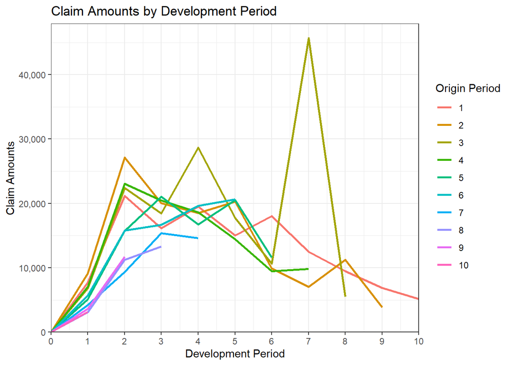

```r
# Incremental claims data:
plotTriangleGraph(Inc_Triangle)
```

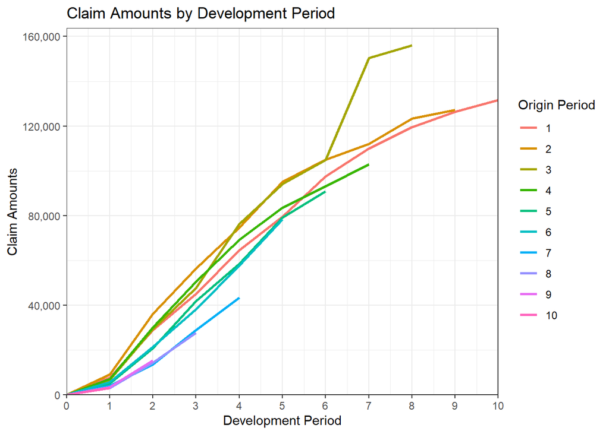

```r
# Cumulative claims data
plotTriangleGraph(Triangle)
```

*Commentary:*

Looking at graphs of the incremental and cumulative amounts, we can see a large incremental value at development period 7 for origin period 3. It is likely that this will be influential on volatility estimates. It is often easier to see this kind of feature when inspecting a graph of incremental values.

### Step 2: Fit a baseline chain ladder model, and identify which link ratios are associated with any unusual behaviour identified at step 1:

```r
# Calculate link ratio triangle and volume-weighted chain ladder factors
LRs <- LR_Tri(Triangle)
CL_facs <- CL_factors(LRs$LRs, LRs$Weight)

print("Triangle of link ratios")
```

```
## [1] "Triangle of link ratios"
```

```r
LRs$LRs
```

```
##           [,1]     [,2]     [,3]     [,4]     [,5]     [,6]     [,7]     [,8]     [,9]
##  [1,] 3.745367 1.559215 1.433120 1.232268 1.226321 1.127851 1.086286 1.057487 1.040665
##  [2,] 3.972736 1.552159 1.328302 1.270847 1.104263 1.067461 1.100624 1.031386       NA
##  [3,] 4.282663 1.630568 1.600168 1.232521 1.113401 1.435636 1.036612       NA       NA
##  [4,] 4.266043 1.680215 1.368315 1.208351 1.113233 1.105506       NA       NA       NA
##  [5,] 4.067238 2.008817 1.399671 1.350137 1.146815       NA       NA       NA       NA
##  [6,] 3.780535 1.777245 1.514420 1.356528       NA       NA       NA       NA       NA
##  [7,] 3.227640 2.131697 1.505756       NA       NA       NA       NA       NA       NA
##  [8,] 4.617836 1.927351       NA       NA       NA       NA       NA       NA       NA
##  [9,] 4.237490       NA       NA       NA       NA       NA       NA       NA       NA
```

```r
print("Chain ladder factors")
```

```
## [1] "Chain ladder factors"
```

```r
CL_facs
```

```
## [1] 4.004287 1.726490 1.441521 1.270500 1.138307 1.187369 1.070538 1.044234 1.040665
```

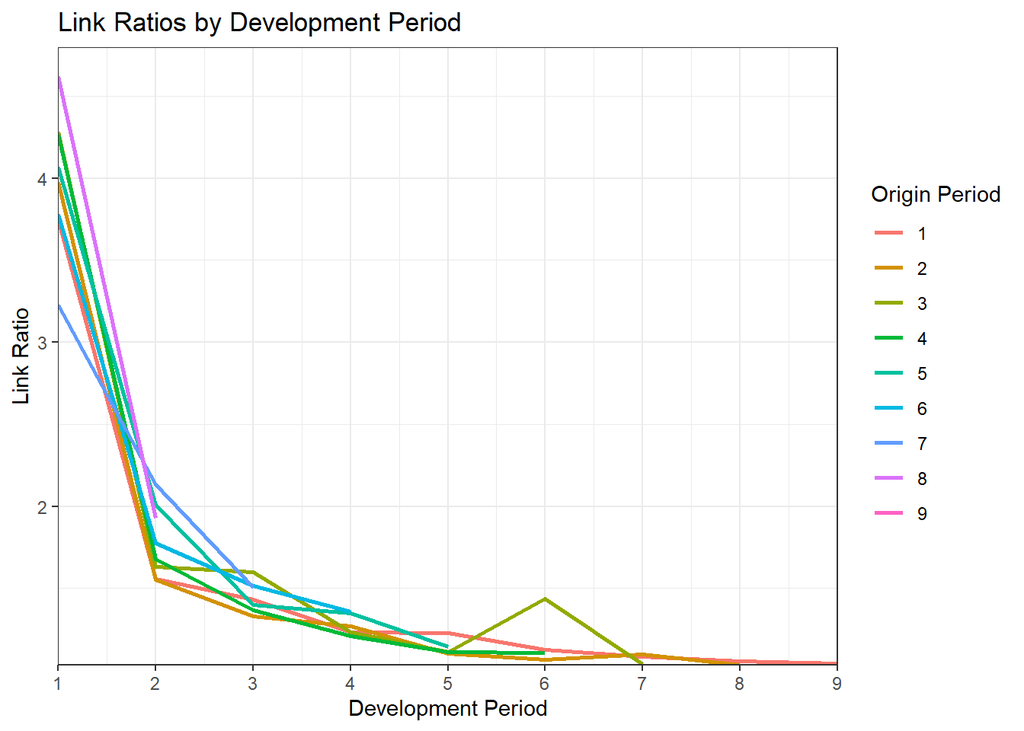

```r
plotLRsGraph(LRs$LRs)
```

```r
# Calculate volume-weighted chain ladder results
CL_Result <- Tri_forecast(Triangle, CL_facs)
Latest_by_yr <- CL_Result$Latest
TotalLatest <- sum(Latest_by_yr)
Latest <- c(Latest_by_yr, TotalLatest)
Reserves_by_yr <- CL_Result$Reserves
TotalReserve <- CL_Result$TotalReserve
Reserves <- c(Reserves_by_yr, TotalReserve)
Ultimates_by_yr <- CL_Result$Ultimates
TotalUltimate <- sum(Ultimates_by_yr)
Ultimates <- c(Ultimates_by_yr, TotalUltimate)

Table_0 <- cbind(round(Latest,0), round(Reserves,0), round(Ultimates,0))
dimnames(Table_0) <- list(c(1:length(Triangle), "Total"), c("Latest", "Reserves", "Ultimates"))
names(dimnames(Table_0)) <- c("Year","Chain Ladder Results")
print(Table_0)
```

```
##        Chain Ladder Results
## Year    Latest Reserves Ultimates
##   1     131590        0    131590
##   2     127208     5173    132381
##   3     155978    13523    169501
##   4     102958    16818    119776
##   5      90853    34645    125498
##   6      78429    44891    123320
##   7      43554    43454     87008
##   8      27644    51963     79607
##   9      15327    60876     76203
##   10      3157    59695     62852
##   Total 776698   331038   1107736
```

*Commentary:*

Consistent with the observation above, we can see a large link ratio at development period 6 for origin period 3 (representing the link ratio between the 6th and 7th development periods). We can also see that this link ratio is impacting the volume-weighted average development factor at development period 6, which reverses the trend of decreasing development factors up until that point.

We observe that including all ratios gives a reserve estimate of 331,038.

### Step 3: Apply Mack’s method analytically to quickly obtain a baseline measure of the standard deviation of the forecasts:

```r
# Mack's model
# Analytic Result using weighted Gaussian GLM and
# recursive formulae from England & Verrall (2002) for RMSEPs
Mack_Analytic_Result <- Mack_ChainLadder(Triangle)
Latest_by_yr <- Mack_Analytic_Result$Latest
TotalLatest <- sum(Latest_by_yr)
Latest <- c(Latest_by_yr, TotalLatest)
Reserves_by_yr <- Mack_Analytic_Result$Reserves
TotalReserve <- Mack_Analytic_Result$TotalReserves
Reserves <- c(Reserves_by_yr, TotalReserve)
Ultimates_by_yr <- Mack_Analytic_Result$Ultimates
TotalUltimate <- sum(Ultimates_by_yr)
Ultimates <- c(Ultimates_by_yr, TotalUltimate)
Mack_Res_SD_by_yr <- Mack_Analytic_Result$Reserves_SD
Mack_Res_TotalSD <- Mack_Analytic_Result$TotalReserve_SD
Mack_Res_SD <- c(Mack_Res_SD_by_yr, Mack_Res_TotalSD)
Mack_Res_CoV <- safe_divide(Mack_Res_SD, abs(Reserves))

Table_1 <- cbind(round(Latest,0), round(Reserves,0), round(Ultimates,0), round(Mack_Res_SD,0), round(100*Mack_Res_CoV,1))
dimnames(Table_1) <- list(c(1:length(Triangle), "Total"), c("Latest", "Reserves", "Ultimates", "Reserve SD", "Reserve CoV %"))
names(dimnames(Table_1)) <- c("Year","Analytic")
Table_1
```

```
##        Analytic
## Year    Latest Reserves Ultimates Reserve SD Reserve CoV %
##   1     131590        0    131590          0           0.0
##   2     127208     5173    132381       3249          62.8
##   3     155978    13523    169501       5186          38.3
##   4     102958    16818    119776       6301          37.5
##   5      90853    34645    125498      22175          64.0
##   6      78429    44891    123320      22779          50.7
##   7      43554    43454     87008      19392          44.6
##   8      27644    51963     79607      19799          38.1
##   9      15327    60876     76203      22494          36.9
##   10      3157    59695     62852      21657          36.3
##   Total 776698   331038   1107736      69077          20.9
```

*Commentary:*

Applying Mack’s model analytically, we observe a standard deviation of 69,077 giving a coefficient of variation of 21%, which is quite high given the cumulative claims show a generally stable pattern.

### Step 4: Calculate unscaled and scaled residuals for Mack’s model, and review the variance parameters (Mack’s sigma):

```r
# Calculate residuals for Mack's model including all ratios:
method <- "Mack"
Resids <- Calc_Residuals(Triangle, method=method)

# show adjusted unscaled residuals
adj_unscaled_resids <- round(Resids$adjunscaledresids,3)
dp_labels_2 <- paste("DP", 1:(length(Triangle)-1), sep=" ")
op_labels_2 <- paste("OP", 1:(length(Triangle)-1), sep=" ")
dimnames(adj_unscaled_resids) <- list(op_labels_2, dp_labels_2)
print("Adjusted unscaled residuals")
```

```
## [1] "Adjusted unscaled residuals"
```

```r
adj_unscaled_resids
```

```
##         DP 1    DP 2    DP 3    DP 4    DP 5    DP 6    DP 7   DP 8 DP 9
## OP 1 -24.125 -30.402  -1.926 -10.644  27.760 -21.470   6.399  6.481   NA
## OP 2  -3.198 -35.499 -29.021   0.104 -11.736 -44.861  12.335 -6.381   NA
## OP 3  24.411 -17.544  37.437 -11.498  -8.544  92.809 -16.118     NA   NA
## OP 4  23.326  -8.585 -17.786 -17.913  -8.108 -28.847      NA     NA   NA
## OP 5   4.783  43.601  -9.255  21.132   2.677      NA      NA     NA   NA
## OP 6 -17.889   7.952  15.385  22.660      NA      NA      NA     NA   NA
## OP 7 -53.411  50.460  11.800      NA      NA      NA      NA     NA   NA
## OP 8  36.268  25.716      NA      NA      NA      NA      NA     NA   NA
## OP 9  14.876      NA      NA      NA      NA      NA      NA     NA   NA
```

```r
# show zero-average scaled residuals
zeroavg_scaled_resids <- round(Resids$zeroavgscaledresids,3)
dp_labels_2 <- paste("DP", 1:(length(Triangle)-1), sep=" ")
op_labels_2 <- paste("OP", 1:(length(Triangle)-1), sep=" ")
dimnames(zeroavg_scaled_resids) <- list(op_labels_2, dp_labels_2)
print("Zero-average adjusted scaled residuals")
```

```
## [1] "Zero-average adjusted scaled residuals"
```

```r
zeroavg_scaled_resids
```

```
##        DP 1   DP 2   DP 3   DP 4   DP 5   DP 6   DP 7   DP 8 DP 9
## OP 1 -0.952 -1.029 -0.144 -0.719  1.860 -0.445  0.469  0.956   NA
## OP 2 -0.171 -1.193 -1.448 -0.045 -0.860 -0.873  0.952 -1.044   NA
## OP 3  0.859 -0.616  1.749 -0.773 -0.640  1.649 -1.364     NA   NA
## OP 4  0.819 -0.328 -0.907 -1.175 -0.610 -0.580     NA     NA   NA
## OP 5  0.127  1.350 -0.497  1.273  0.133     NA     NA     NA   NA
## OP 6 -0.719  0.204  0.688  1.369     NA     NA     NA     NA   NA
## OP 7 -2.045  1.571  0.516     NA     NA     NA     NA     NA   NA
## OP 8  1.302  0.775     NA     NA     NA     NA     NA     NA   NA
## OP 9  0.503     NA     NA     NA     NA     NA     NA     NA   NA
```

```r
# Show variance parameters (Mack's sigma or ODP sqrtScale)
sigma <- round(Resids$sqrtScale, 1)
names(sigma) <- paste0("DP", 1:(length(Triangle)-1), sep=" ")
cat("Mack's sigma parameters:\n")
```

```
## Mack's sigma parameters:
```

```r
sigma
```

```
## DP1  DP2  DP3  DP4  DP5  DP6  DP7  DP8  DP9
## 26.8 31.1 20.8 15.9 14.5 54.6 12.3  6.4  6.4
```

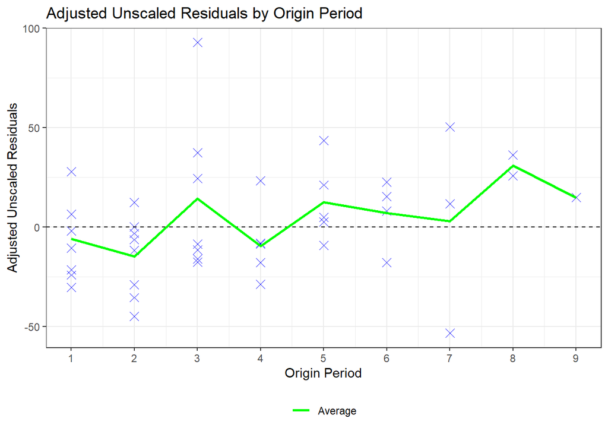

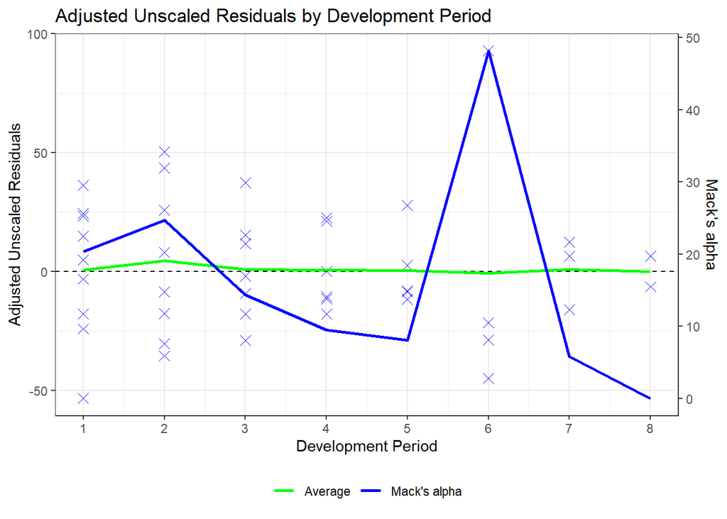

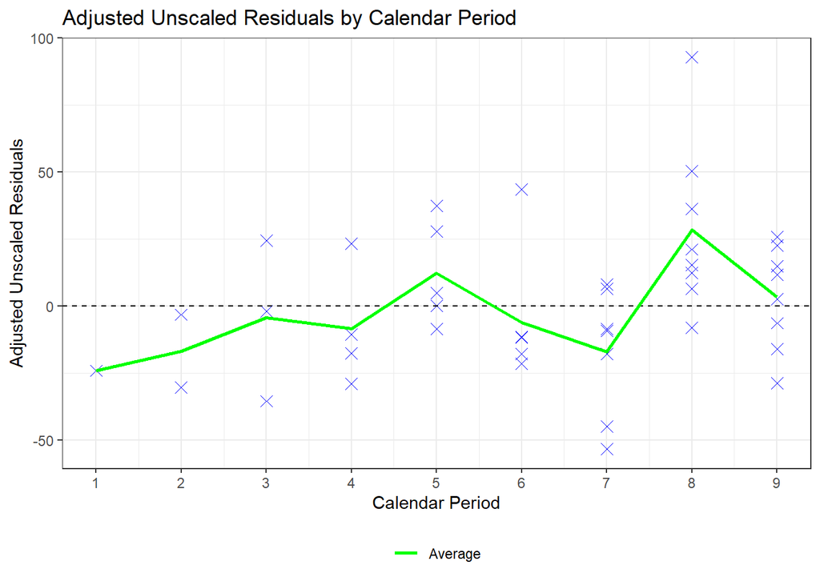

```r
sigma_original <- Resids$sqrtScale # save for later

# plot residuals
plotResiduals(Resids, resid_type="adjunscaledresids", bstrap_method=method)
```

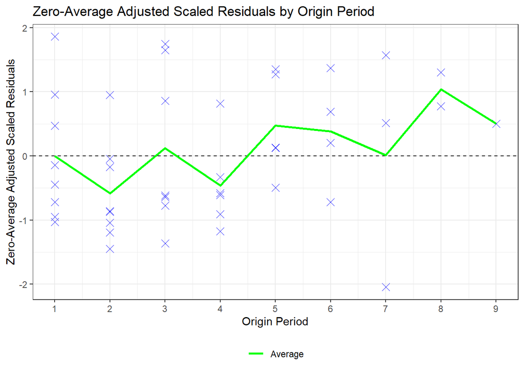

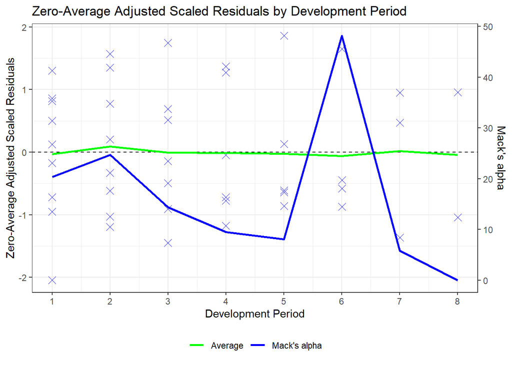

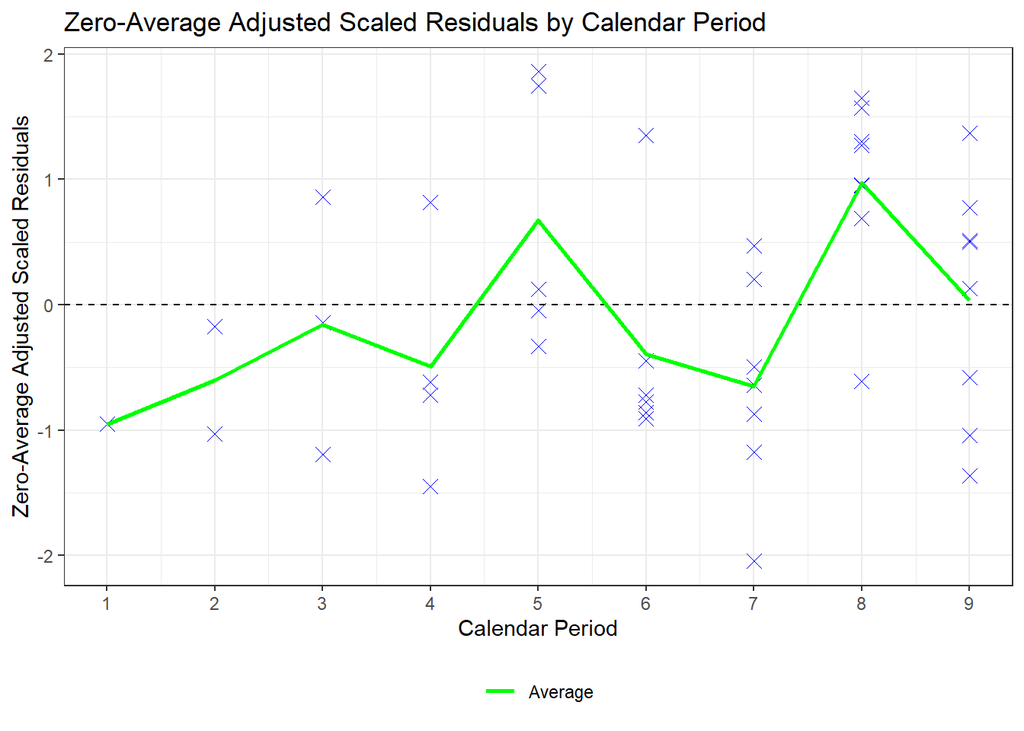

```r
plotResiduals(Resids, resid_type="zeroavgscaledresids", bstrap_method=method)
```

*Commentary:*

The unscaled residuals are generally difficult to interpret, since we have no reference point for their range. However, we can see that the range is generally reducing by development period, except at development period 6 (Mack’s model is really a model of the link ratios, so for a 10 by 10 triangle there is a 9 by 9 triangle of residuals, and the 6th development factor represents the development between the 6th and 7th development periods).

The (adjusted) unscaled residuals are used to estimate Mack’s sigma parameters (the variance parameters). The sigma parameters are estimated as the square root of the average squared adjusted unscaled residuals at each development period. A large unscaled residual will cause Mack’s sigma to be large.

We can see that the unscaled residual at development period 6 for origin period 3 is large, causing Mack’s sigma to spike at that point when the other values are decreasing. Dividing the unscaled residuals by Mack’s sigma scales the residuals in a way that they can now be interpreted like Gaussian theory residuals. That is, we expect them to be approximately i.i.d. with mean 0 and variance 1. We expect a pattern free set of residuals when plotting them by origin, development and calendar period, and we expect 95% to be (approximately) in the range +/- 2. We still expect 5% to be outside that range.

The main concern with this example is the high value of Mack’s sigma at development period 6, which is driven by the large incremental value at development period 7, which impacts the link ratio between the 6th and 7th development periods for origin period 3.

### Step 5: Apply a bootstrap model using Mack’s assumptions with all link ratios included, and review the summary statistics:

```r
## Bootstrap settings:
## method = "Mack", "ODPConstant", "ODPNonConstant", "NegBinConstant", or "NegBinNonConstant"
## (For ODP and NegBin, NonConstant is usually more appropriate)
## replications = number of bootstrap replications
## seed = seed point for random number generator (if blank, it is different each time)
## BootstrapDist = "NP" for non-parametric, or "Gamma" or "Lognormal" for parametric (this is for the pseudo_data distribution)
## ForecastDist = "NP" for non-parametric, or "Gamma" or "Lognormal" for parametric (this is for the process distribution)

# Select bootstrap method
method <- "Mack"

#BootstrapDist = "NP" # non-parametric bootstrapping
BootstrapDist = "Gamma" # generating pseudo-data with Gamma distribution
#BootstrapDist = "Lognormal" # generating pseudo-data with Lognormal distribution

#ForecastDist <- "NP" # non-parametric forecasting
ForecastDist <- "Gamma" # forecasting with Gamma distribution
#ForecastDist <- "Lognormal" # forecasting with Lognormal distribution

replications <- 10000
seed <- 100 # seed point for bootstrapping

UserSqrtScale <- NULL # do not use user-defined scale parameters initially

Mack_Bstrap_Result <- Run_Bootstrap(Triangle, method=method,
                               replications=replications, seed=seed, BootstrapDist=BootstrapDist,
                               ForecastDist=ForecastDist, UserSqrtScale=UserSqrtScale)

#Table of results
Table_2 <- cbind(round(Mack_Bstrap_Result$Latest,0), round(Mack_Bstrap_Result$Avg_Reserve,0),
                 round(Mack_Bstrap_Result$Latest+Mack_Bstrap_Result$Avg_Reserve,0),
                 round(Mack_Bstrap_Result$SD_Reserve,0), round(100*Mack_Bstrap_Result$CoV_Reserve,1))
Table_2_Totals <- cbind(round(sum(Mack_Bstrap_Result$Latest),0), round(Mack_Bstrap_Result$Avg_TotalReserve,0),
                        round(sum(Mack_Bstrap_Result$Latest)+Mack_Bstrap_Result$Avg_TotalReserve,0),
                        round(Mack_Bstrap_Result$SD_TotalReserve,0), round(100*Mack_Bstrap_Result$CoV_TotalReserve,1))
Table_2 <- rbind(Table_2, Table_2_Totals)
dimnames(Table_2) <- list(c(1:length(Triangle), "Total"), c("Latest", "Avg Reserves",
                                                            "Avg Ultimates", "Bstrap SD", "Reserves CoV %"))
names(dimnames(Table_2)) <- c("Year","Simulated (Undiscounted)")
Table_2
```

```
##        Simulated (Undiscounted)
## Year    Latest Avg Reserves Avg Ultimates Bstrap SD Reserves CoV %
##   1     131590            0        131590         0            0.0
##   2     127208         5192        132400      3234           62.3
##   3     155978        13445        169423      5223           38.8
##   4     102958        16839        119797      6324           37.6
##   5      90853        34631        125484     21938           63.3
##   6      78429        44939        123368     22804           50.7
##   7      43554        43535         87089     19278           44.3
##   8      27644        52218         79862     19756           37.8
##   9      15327        60544         75871     22287           36.8
##   10      3157        59830         62987     21658           36.2
##   Total 776698       331172       1107870     68653           20.7
```

```r
# Show set of summary statistics
ShowStats <- ShowSummaryStats(Mack_Bstrap_Result, Output="Reserves")
```

```
## [1] "Simulation Summary Statistics - Reserves"
##                              OP.1  OP.2  OP.3  OP.4   OP.5   OP.6   OP.7   OP.8   OP.9  OP.10  Total
## Mean                            0  5192 13445 16839  34631  44939  43535  52218  60544  59830 331172
## Standard Deviation              0  3234  5223  6324  21938  22804  19278  19756  22287  21658  68653
## Coefficient of Variation (%)  0.0  62.3  38.8  37.6   63.3   50.7   44.3   37.8   36.8   36.2   20.7
## Minimum                         0 -7673 -3680 -5561 -37054 -24751 -15079  -3132  -1460   3933 104464
## 0.5th Percentile                0 -3156   366   472 -15381  -7493  -1012   8948  13302  15631 166881
## 1st Percentile                  0 -2390  1583  2302 -10854  -3347   2829  12296  15930  18646 182546
## 5th Percentile                  0  -116  4916  6753    121   8728  13333  21849  27311  27780 222106
## 10th Percentile                 0  1100  6803  8846   7094  16351  19700  27884  33472  33348 243892
## 25th Percentile                 0  3036  9851 12500  19073  28888  29924  38354  44809  44059 283582
## 50th Percentile (Median)        0  5169 13394 16746  33920  43887  42624  50777  58623  57857 329792
## 75th Percentile                 0  7381 16923 20965  48763  60059  55929  64807  74248  73438 376066
## 90th Percentile                 0  9324 20217 25068  63316  74940  68594  78085  90032  88434 420566
## 95th Percentile                 0 10551 22117 27457  72565  83321  76630  86562  99410  98594 446704
## 99th Percentile                 0 12751 25673 31851  90186 102289  92911 102625 120164 118782 500735
## 99.5th Percentile               0 13496 27321 33455  96176 108130  98581 109117 128058 126159 517729
## Maximum                         0 17063 38284 45249 135627 141494 132804 152765 170024 166022 585573
```

```r
ShowStats <- ShowSummaryStats(Mack_Bstrap_Result, Output="Ultimates")
```

```
## [1] "Simulation Summary Statistics - Ultimates"
##                                OP.1   OP.2   OP.3   OP.4   OP.5   OP.6   OP.7   OP.8   OP.9  OP.10   Total
## Mean                         131590 132400 169423 119797 125484 123368  87089  79862  75871  62987 1107870
## Standard Deviation                0   3234   5223   6324  21938  22804  19278  19756  22287  21658   68653
## Coefficient of Variation (%)    0.0    2.4    3.1    5.3   17.5   18.5   22.1   24.7   29.4   34.4     6.2
## Minimum                      131590 119535 152298  97397  53799  53678  28475  24512  13867   7090  881162
## 0.5th Percentile             131590 124052 156344 103430  75472  70936  42542  36592  28629  18788  943579
## 1st Percentile               131590 124818 157561 105260  79999  75082  46383  39940  31257  21803  959244
## 5th Percentile               131590 127092 160894 109711  90974  87157  56887  49493  42638  30937  998804
## 10th Percentile              131590 128308 162781 111804  97947  94780  63254  55528  48799  36505 1020590
## 25th Percentile              131590 130244 165829 115458 109926 107317  73478  65998  60136  47216 1060280
## 50th Percentile (Median)     131590 132377 169372 119704 124773 122316  86178  78421  73950  61014 1106490
## 75th Percentile              131590 134589 172901 123923 139616 138488  99483  92451  89575  76595 1152764
## 90th Percentile              131590 136532 176195 128026 154169 153369 112148 105729 105359  91591 1197264
## 95th Percentile              131590 137759 178095 130415 163418 161750 120184 114206 114737 101751 1223402
## 99th Percentile              131590 139959 181651 134809 181039 180718 136465 130269 135491 121939 1277433
## 99.5th Percentile            131590 140704 183299 136413 187029 186559 142135 136761 143385 129316 1294427
## Maximum                      131590 144271 194262 148207 226480 219923 176358 180409 185351 169179 1362271
```

*Commentary:*

Bootstrapping Mack’s model with all link ratios included, we observe that the mean, standard deviation and coefficient of variation of the reserves in total and by origin period all match closely the results from Mack’s model applied analytically.

### Step 5 (continued): Review the reserve development (fan) graphs:

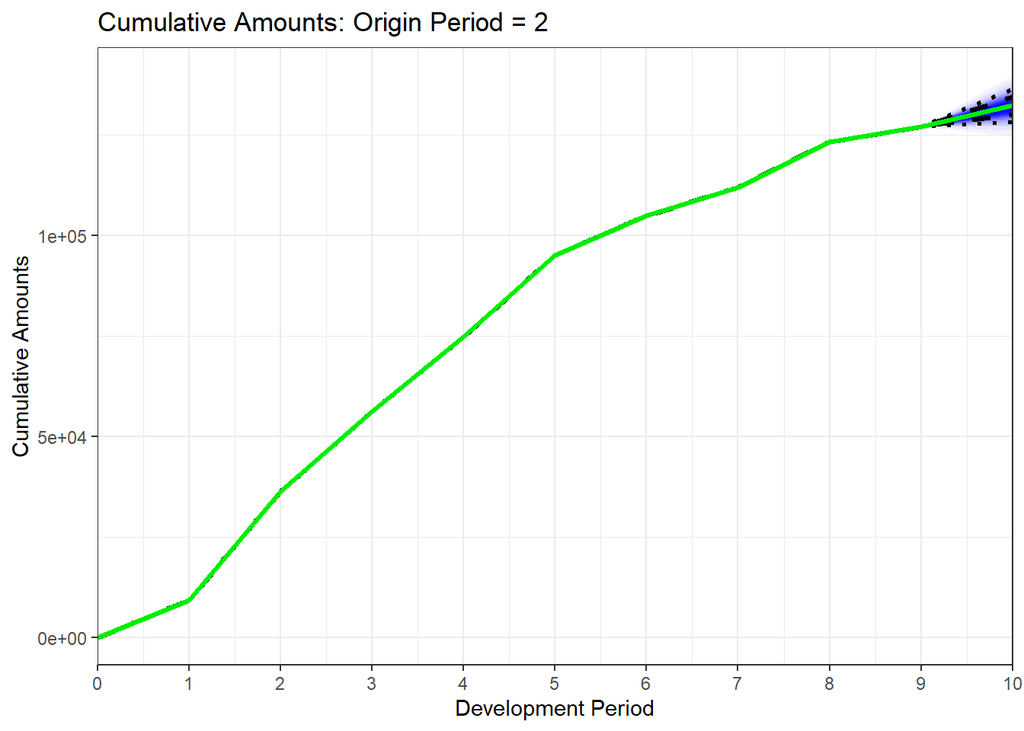

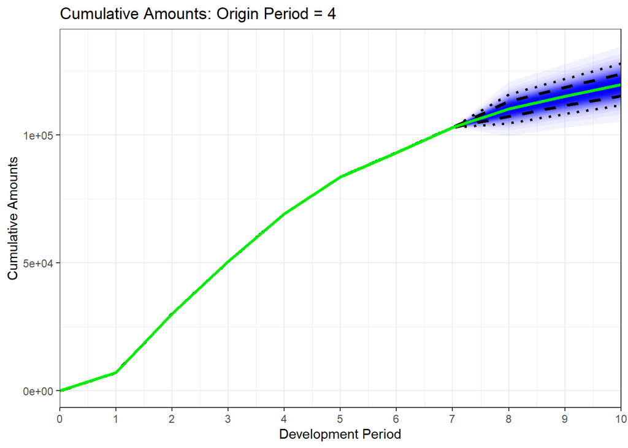

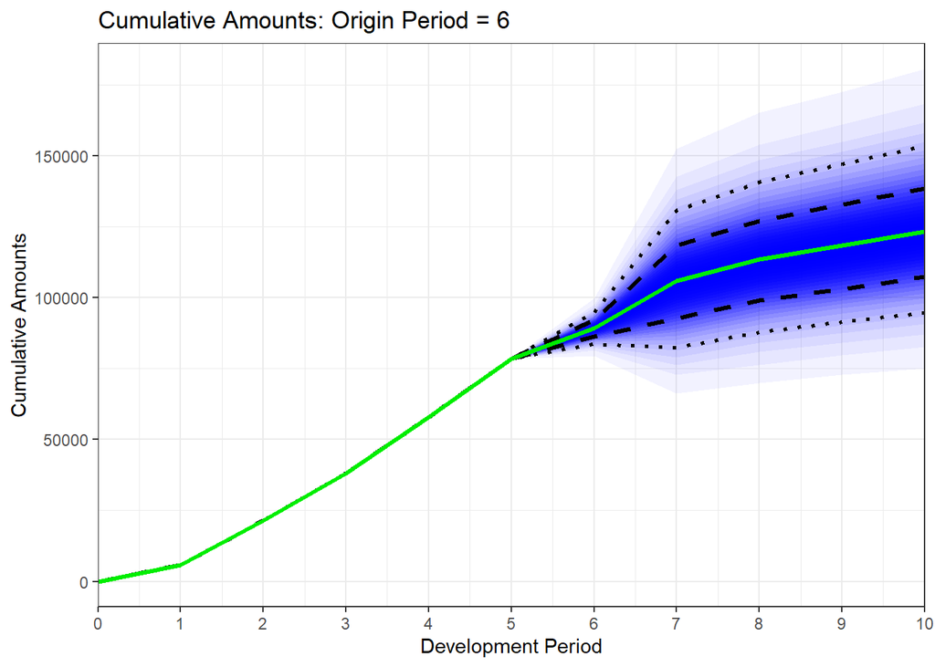

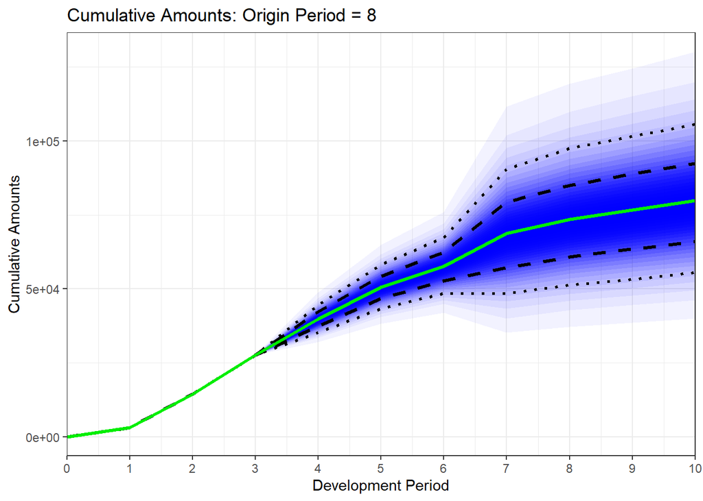

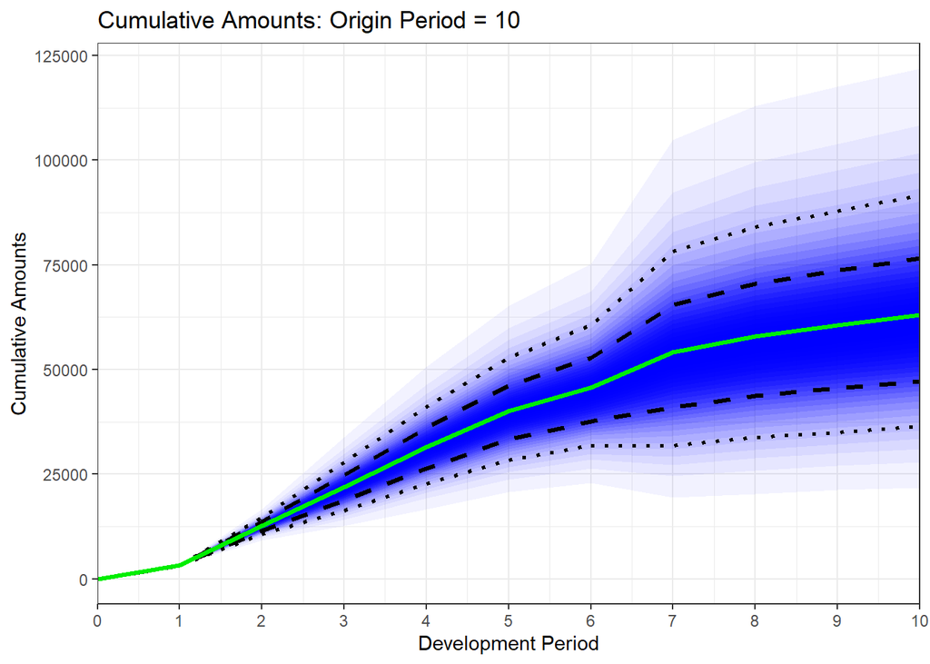

```r
BStrap_Cumulatives <- Mack_Bstrap_Result$Cumulatives

for (yr in seq(2, ncol(BStrap_Cumulatives), by = 2)) {
  print(plotDevelopmentGraph(BStrap_Cumulatives,yr))
}
```

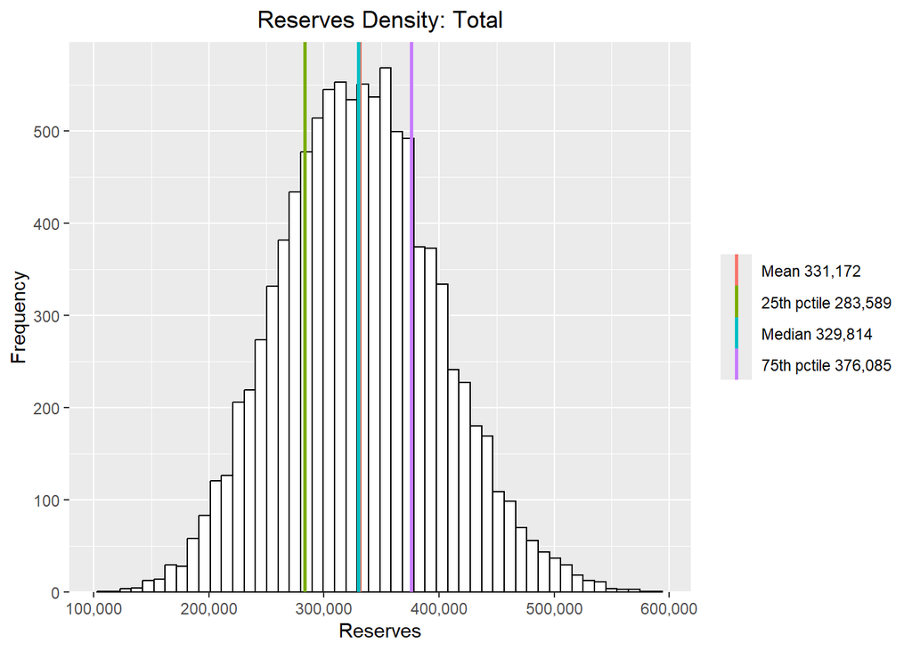

```r
# Histograms - Bootstrap undiscounted reserves
plotHistogram_Total(Mack_Bstrap_Result$TotalReserve)
```

```r
#plotHistogram_by_yr(Mack_Bstrap_Result$Reserves)
```

*Commentary:*

The reserve development (fan) charts are useful since they tell us a lot about the characteristics of the model and forecasts. In this example, we can see that:

1. For the older origin periods, the cumulative amounts reduce for some simulations, and the minimum simulated ultimates are less than the latest payments. This is a characeristic of bootstrapping Mack’s model. Although the simulated cumulative amounts must be positive, they could be less than the previous cumulative amounts.
2. The fan charts suddenly expand at development period 7. This is a direct result of the large value of Mack’s sigma observed at development period 6, impacting the cumulative claims development between the 6th and 7th development periods.

### Step 6: Perform a sensitivity analysis:

```r
# Calculate sensitivities of each link ratio to Chain-ladder reserves and Mack's SD
# Use Mack's SD calculated analytically for speed
# This is a quick and dirty way to identify influential data points
Sensitivity_Results <- Sensitivities(Triangle)

print("Total Reserves")
```

```
## [1] "Total Reserves"
```

```r
Sensitivity_Results$S_Reserves
```

```
##         [,1]   [,2]   [,3]   [,4]   [,5]   [,6]   [,7]   [,8] [,9]
##  [1,] 331739 333385 331256 332801 323540 339993 326879 320656   NA
##  [2,] 331142 334251 334870 331019 334662 350928 322888 341747   NA
##  [3,] 330384 332404 326637 333185 333656 289946 345512     NA   NA
##  [4,] 330400 331719 333215 334154 333310 342621     NA     NA   NA
##  [5,] 330931 328310 332035 327759 330317     NA     NA     NA   NA
##  [6,] 331464 330532 329478 327556     NA     NA     NA     NA   NA
##  [7,] 332100 328595 330031     NA     NA     NA     NA     NA   NA
##  [8,] 330432 329752     NA     NA     NA     NA     NA     NA   NA
##  [9,] 330767     NA     NA     NA     NA     NA     NA     NA   NA
```

```r
print("Total Reserve differences")
```

```
## [1] "Total Reserve differences"
```

```r
Sensitivity_Results$S_Reserves_diff
```

```
##         [,1]    [,2]    [,3]    [,4]    [,5]     [,6]    [,7]     [,8] [,9]
##  [1,]  700.6  2346.8   217.8  1763.3 -7497.7   8955.1 -4158.7 -10382.1   NA
##  [2,]  104.3  3213.1  3831.7   -19.1  3623.6  19890.3 -8150.0  10708.8   NA
##  [3,] -654.2  1365.9 -4400.7  2146.5  2617.8 -41092.5 14474.0       NA   NA
##  [4,] -638.5   681.4  2176.6  3115.7  2271.6  11582.7      NA       NA   NA
##  [5,] -107.1 -2727.8   997.4 -3279.5  -720.7       NA      NA       NA   NA
##  [6,]  426.4  -506.5 -1560.3 -3481.9      NA       NA      NA       NA   NA
##  [7,] 1061.5 -2443.1 -1007.2      NA      NA       NA      NA       NA   NA
##  [8,] -605.8 -1285.6      NA      NA      NA       NA      NA       NA   NA
##  [9,] -270.9      NA      NA      NA      NA       NA      NA       NA   NA
```

```r
print("Total Reserve difference ranks")
```

```
## [1] "Total Reserve difference ranks"
```

```r
Sensitivity_Results$S_Reserves_rank
```

```
##       [,1] [,2] [,3] [,4] [,5] [,6] [,7] [,8] [,9]
##  [1,]   26   34   23   30    4   40    6    2   NA
##  [2,]   22   37   39   21   38   44    3   41   NA
##  [3,]   15   29    5   31   35    1   43   NA   NA
##  [4,]   16   25   32   36   33   42   NA   NA   NA
##  [5,]   20    9   27    8   14   NA   NA   NA   NA
##  [6,]   24   18   11    7   NA   NA   NA   NA   NA
##  [7,]   28   10   13   NA   NA   NA   NA   NA   NA
##  [8,]   17   12   NA   NA   NA   NA   NA   NA   NA
##  [9,]   19   NA   NA   NA   NA   NA   NA   NA   NA
```

```r
print("Total Reserve SDs")
```

```
## [1] "Total Reserve SDs"
```

```r
Sensitivity_Results$S_ReservesSD
```

```
##        [,1]  [,2]  [,3]  [,4]  [,5]  [,6]  [,7]  [,8] [,9]
##  [1,] 69165 69349 69382 69449 67236 83244 70944 79326   NA
##  [2,] 69155 69312 69272 69392 69723 77698 68918 81125   NA
##  [3,] 69022 69462 68097 69477 69776 38390 66935    NA   NA
##  [4,] 69028 69477 69411 69382 69740 81693    NA    NA   NA
##  [5,] 69129 68552 69413 68609 69576    NA    NA    NA   NA
##  [6,] 69159 69352 69061 68524    NA    NA    NA    NA   NA
##  [7,] 69015 68397 69165    NA    NA    NA    NA    NA   NA
##  [8,] 68971 69084    NA    NA    NA    NA    NA    NA   NA
##  [9,] 69095    NA    NA    NA    NA    NA    NA    NA   NA
```

```r
print("Total Reserve SD diferences")
```

```
## [1] "Total Reserve SD diferences"
```

```r
Sensitivity_Results$S_ReservesSD_diff
```

```
##         [,1]   [,2]   [,3]   [,4]    [,5]     [,6]    [,7]    [,8] [,9]
##  [1,]   87.2  271.3  304.6  371.5 -1841.2  14166.4  1866.2 10248.1   NA
##  [2,]   77.3  234.0  194.5  314.9   645.4   8620.5  -159.6 12047.6   NA
##  [3,]  -55.3  384.3 -980.8  399.9   698.2 -30687.6 -2142.0      NA   NA
##  [4,]  -49.2  399.0  333.5  304.1   662.9  12615.2      NA      NA   NA
##  [5,]   51.4 -525.7  336.0 -468.7   498.5       NA      NA      NA   NA
##  [6,]   82.0  274.5  -16.0 -554.0      NA       NA      NA      NA   NA
##  [7,]  -62.1 -680.8   87.4     NA      NA       NA      NA      NA   NA
##  [8,] -106.9    6.5     NA     NA      NA       NA      NA      NA   NA
##  [9,]   17.1     NA     NA     NA      NA       NA      NA      NA   NA
```

```r
print("Total Reserve SD ranks")
```

```
## [1] "Total Reserve SD ranks"
```

```r
Sensitivity_Results$S_ReservesSD_rank
```

```
##       [,1] [,2] [,3] [,4] [,5] [,6] [,7] [,8] [,9]
##  [1,]   20   24   27   31    3   44   39   41   NA
##  [2,]   18   23   22   28   36   40    9   42   NA
##  [3,]   12   32    4   34   38    1    2   NA   NA
##  [4,]   13   33   29   26   37   43   NA   NA   NA
##  [5,]   17    7   30    8   35   NA   NA   NA   NA
##  [6,]   19   25   14    6   NA   NA   NA   NA   NA
##  [7,]   11    5   21   NA   NA   NA   NA   NA   NA
##  [8,]   10   15   NA   NA   NA   NA   NA   NA   NA
##  [9,]   16   NA   NA   NA   NA   NA   NA   NA   NA
```

```r
print("Total Reserve CoVs")
```

```
## [1] "Total Reserve CoVs"
```

```r
Sensitivity_Results$S_ReservesCoV*100
```

```
##       [,1] [,2] [,3] [,4] [,5] [,6] [,7] [,8] [,9]
##  [1,] 20.8 20.8 20.9 20.9 20.8 24.5 21.7 24.7   NA
##  [2,] 20.9 20.7 20.7 21.0 20.8 22.1 21.3 23.7   NA
##  [3,] 20.9 20.9 20.8 20.9 20.9 13.2 19.4   NA   NA
##  [4,] 20.9 20.9 20.8 20.8 20.9 23.8   NA   NA   NA
##  [5,] 20.9 20.9 20.9 20.9 21.1   NA   NA   NA   NA
##  [6,] 20.9 21.0 21.0 20.9   NA   NA   NA   NA   NA
##  [7,] 20.8 20.8 21.0   NA   NA   NA   NA   NA   NA
##  [8,] 20.9 21.0   NA   NA   NA   NA   NA   NA   NA
##  [9,] 20.9   NA   NA   NA   NA   NA   NA   NA   NA
```

```r
print("Total Reserve CoV differences")
```

```
## [1] "Total Reserve CoV differences"
```

```r
Sensitivity_Results$S_ReservesCoV_diff*100
```

```
##       [,1] [,2] [,3] [,4] [,5] [,6] [,7] [,8] [,9]
##  [1,]  0.0 -0.1  0.1  0.0 -0.1  3.6  0.8  3.9   NA
##  [2,]  0.0 -0.1 -0.2  0.1  0.0  1.3  0.5  2.9   NA
##  [3,]  0.0  0.0  0.0  0.0  0.0 -7.6 -1.5   NA   NA
##  [4,]  0.0  0.1  0.0 -0.1  0.1  3.0   NA   NA   NA
##  [5,]  0.0  0.0  0.0  0.1  0.2   NA   NA   NA   NA
##  [6,]  0.0  0.1  0.1  0.1   NA   NA   NA   NA   NA
##  [7,] -0.1 -0.1  0.1   NA   NA   NA   NA   NA   NA
##  [8,]  0.0  0.1   NA   NA   NA   NA   NA   NA   NA
##  [9,]  0.0   NA   NA   NA   NA   NA   NA   NA   NA
```

```r
print("Total Reserve CoV ranks")
```

```
## [1] "Total Reserve CoV ranks"
```

```r
Sensitivity_Results$S_ReservesCoV_rank
```

```
##       [,1] [,2] [,3] [,4] [,5] [,6] [,7] [,8] [,9]
##  [1,]   13    8   31   16    6   43   39   44   NA
##  [2,]   19    4    3   35   11   40   38   41   NA
##  [3,]   22   24   12   14   26    1    2   NA   NA
##  [4,]   23   30   10    5   28   42   NA   NA   NA
##  [5,]   21   18   25   29   37   NA   NA   NA   NA
##  [6,]   15   36   34   27   NA   NA   NA   NA   NA
##  [7,]    7    9   33   NA   NA   NA   NA   NA   NA
##  [8,]   17   32   NA   NA   NA   NA   NA   NA   NA
##  [9,]   20   NA   NA   NA   NA   NA   NA   NA   NA
```

*Commentary:*

Excluding each link ratio in turn and recalculating Mack’s model applied analytically is a quick way to identify influential link ratios.

In this example, the total reserves, standard deviation of the total reserves, and coefficient of variation of the total reserves are shown as each link ratio is excluded. The reductions in reserves, standard deviations, and coefficients of variation are then shown and ranked according to the largest reductions.

The link ratio at development period 7 for origin period 3 then causes the second biggest reduction in standard deviation and coefficient of variation, but the reduction is much smaller.

### Step 7: Identify and exclude the top *n* influential ratios (eg top 3) and re-apply Mack’s method analytically:

```r
Masktmp <- matrix(1,nrow(Triangle)-1, ncol(Triangle)-1) # include all data initially
#Indicators[3,6] <- 0

# Find positions of top 3 ranks using Total Reserve SDs
for (rank_num in c(1, 2, 3)) {
  positions <- which(Sensitivity_Results$S_ReservesSD_rank == rank_num, arr.ind = TRUE)
  pos <- positions[1, ]
  Masktmp[pos[1], pos[2]] <- 0
}

# Apply Mack's method analytically, excluding the top 3 influential link ratios
Mack_Analytic_Result <- Mack_ChainLadder(Triangle, Mask=Masktmp)
Latest_by_yr <- Mack_Analytic_Result$Latest
TotalLatest <- sum(Latest_by_yr)
Latest <- c(Latest_by_yr, TotalLatest)
Reserves_by_yr <- Mack_Analytic_Result$Reserves
TotalReserve <- Mack_Analytic_Result$TotalReserves
Reserves <- c(Reserves_by_yr, TotalReserve)
Ultimates_by_yr <- Mack_Analytic_Result$Ultimates
TotalUltimate <- sum(Ultimates_by_yr)
Ultimates <- c(Ultimates_by_yr, TotalUltimate)
Mack_Res_SD_by_yr <- Mack_Analytic_Result$Reserves_SD
Mack_Res_TotalSD <- Mack_Analytic_Result$TotalReserve_SD
Mack_Res_SD <- c(Mack_Res_SD_by_yr, Mack_Res_TotalSD)
Mack_Res_CoV <- safe_divide(Mack_Res_SD, abs(Reserves))

Table_1 <- cbind(round(Latest,0), round(Reserves,0), round(Ultimates,0), round(Mack_Res_SD,0), round(100*Mack_Res_CoV,1))
dimnames(Table_1) <- list(c(1:length(Triangle), "Total"), c("Latest", "Reserves", "Ultimates", "Reserve SD", "Reserve CoV %"))
names(dimnames(Table_1)) <- c("Year","Analytic")
Table_1
```

```
##        Analytic
## Year    Latest Reserves Ultimates Reserve SD Reserve CoV %
##   1     131590        0    131590          0           0.0
##   2     127208     5173    132381       1707          33.0
##   3     155978    13523    169501       3966          29.3
##   4     102958    19390    122348       3464          17.9
##   5      90853    27839    118692       5236          18.8
##   6      78429    36164    114593       5567          15.4
##   7      43554    37297     80851       6813          18.3
##   8      27644    46330     73974       9317          20.1
##   9      15327    55484     70811      14044          25.3
##   10      3157    55247     58404      14546          26.3
##   Total 776698   296446   1073144      30355          10.2
```

*Commentary:*

If the top 3 link ratios influencing the standard deviation are excluded, the reserves reduce from 331k to 296k, the standard deviation reduces from 69k to 30k, and the coefficient of variation reduces from 21% to 10%.

It may not be appropriate to exclude any of the link ratios (that is for the analyst to justify), but we are in a more informed position knowing which data points are driving volatility.

### Step 8: Investigate the impact of influential link ratios on the residuals and variance parameters for the Mack’s model:

```r
method <- "Mack"
Resids <- Calc_Residuals(Triangle, method=method, Mask=Masktmp)

# show adjusted unscaled residuals
adj_unscaled_resids <- round(Resids$adjunscaledresids,3)
dp_labels_2 <- paste("DP", 1:(length(Triangle)-1), sep=" ")
op_labels_2 <- paste("OP", 1:(length(Triangle)-1), sep=" ")
dimnames(adj_unscaled_resids) <- list(op_labels_2, dp_labels_2)
print("Adjusted scaled residuals")
```

```
## [1] "Adjusted scaled residuals"
```

```r
adj_unscaled_resids
```

```
##         DP 1    DP 2    DP 3    DP 4   DP 5    DP 6   DP 7   DP 8 DP 9
## OP 1 -24.125 -30.402  -1.926 -10.644     NA  10.896 -3.394  6.481   NA
## OP 2  -3.198 -35.499 -29.021   0.104 -5.037 -12.664  3.364 -6.381   NA
## OP 3  24.411 -17.544  37.437 -11.498 -1.775      NA     NA     NA   NA
## OP 4  23.326  -8.585 -17.786 -17.913 -1.730   2.292     NA     NA   NA
## OP 5   4.783  43.601  -9.255  21.132  9.231      NA     NA     NA   NA
## OP 6 -17.889   7.952  15.385  22.660     NA      NA     NA     NA   NA
## OP 7 -53.411  50.460  11.800      NA     NA      NA     NA     NA   NA
## OP 8  36.268  25.716      NA      NA     NA      NA     NA     NA   NA
## OP 9  14.876      NA      NA      NA     NA      NA     NA     NA   NA
```

```r
# show zero-average scaled residuals
zeroavg_scaled_resids <- round(Resids$zeroavgscaledresids,3)
dp_labels_2 <- paste("DP", 1:(length(Triangle)-1), sep=" ")
op_labels_2 <- paste("OP", 1:(length(Triangle)-1), sep=" ")
dimnames(zeroavg_scaled_resids) <- list(op_labels_2, dp_labels_2)
print("Zero-average adjusted scaled residuals")
```

```
## [1] "Zero-average adjusted scaled residuals"
```

```r
zeroavg_scaled_resids
```

```
##        DP 1   DP 2   DP 3   DP 4   DP 5   DP 6   DP 7   DP 8 DP 9
## OP 1 -0.952 -1.030 -0.145 -0.719     NA  1.067 -1.057  0.956   NA
## OP 2 -0.171 -1.194 -1.448 -0.046 -0.985 -1.353  0.943 -1.044   NA
## OP 3  0.859 -0.616  1.749 -0.773 -0.381     NA     NA     NA   NA
## OP 4  0.818 -0.328 -0.908 -1.175 -0.372  0.183     NA     NA   NA
## OP 5  0.126  1.350 -0.497  1.273  1.657     NA     NA     NA   NA
## OP 6 -0.720  0.204  0.688  1.369     NA     NA     NA     NA   NA
## OP 7 -2.045  1.570  0.516     NA     NA     NA     NA     NA   NA
## OP 8  1.301  0.775     NA     NA     NA     NA     NA     NA   NA
## OP 9  0.503     NA     NA     NA     NA     NA     NA     NA   NA
```

```r
# Show variance parameters (Mack's sigma or ODP sqrtScale)
sigma <- round(Resids$sqrtScale, 1)
names(sigma) <- paste0("DP", 1:(length(Triangle)-1), sep=" ")
cat("Mack's sigma parameters:\n")
```

```
## Mack's sigma parameters:
```

```r
sigma
```

```
## DP1  DP2  DP3  DP4  DP5  DP6  DP7  DP8  DP9
## 26.8 31.1 20.8 15.9  5.4  9.7  3.4  6.4  3.4
```

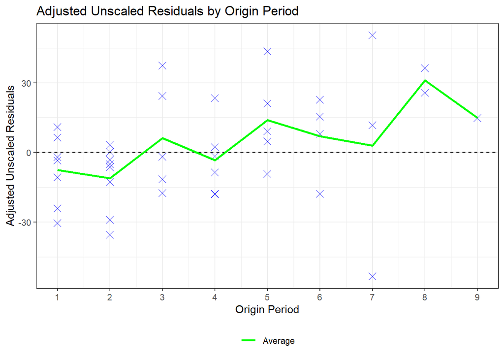

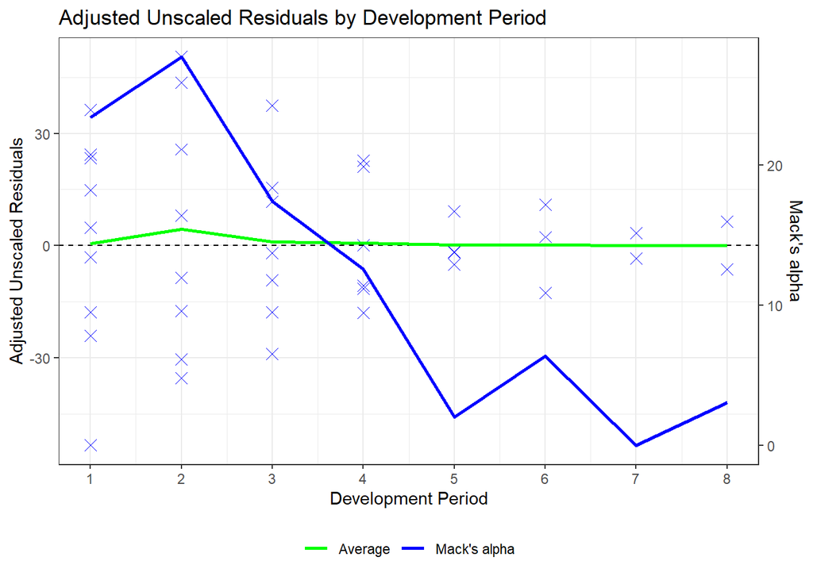

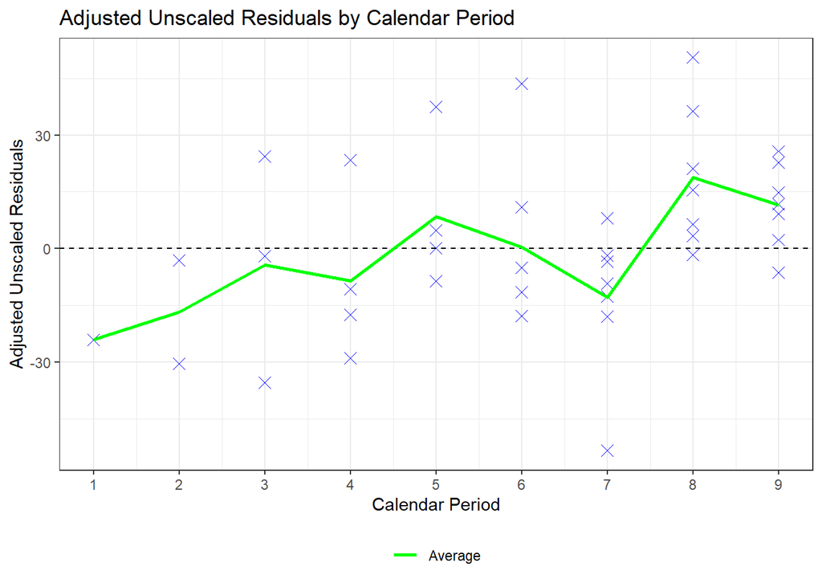

```r
# Plot residuals
plotResiduals(Resids, resid_type="adjunscaledresids", bstrap_method=method)
```

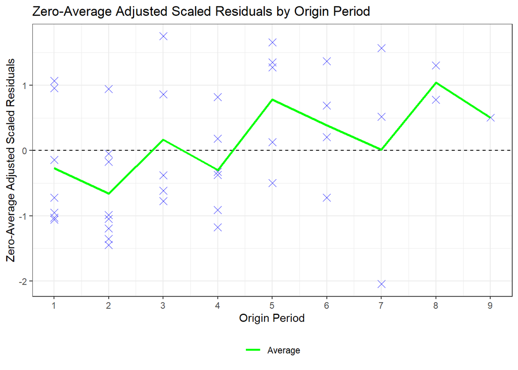

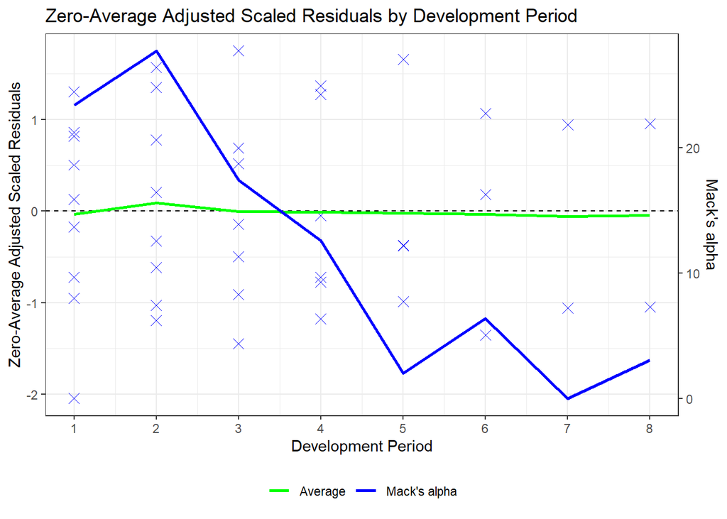

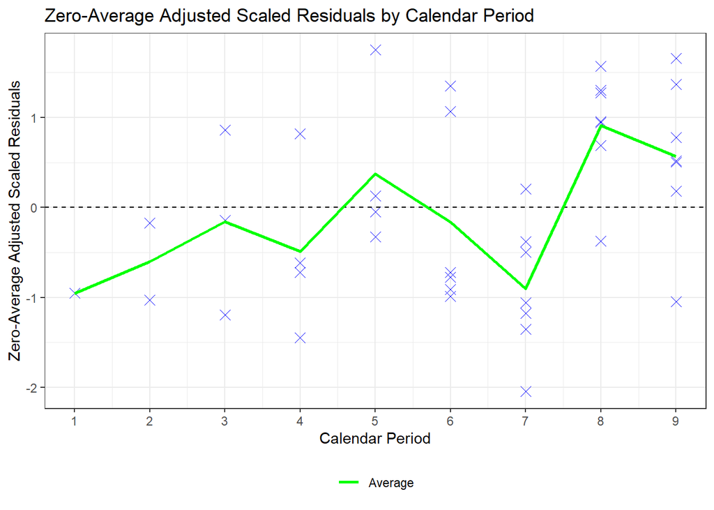

```r
plotResiduals(Resids, resid_type="zeroavgscaledresids", bstrap_method=method)
```

*Commentary:*

Excluding link ratios also excludes the associated residuals, which has a follow-on impact on the calculation of the parameters in the variance. In particular, excluding the link ratio at development period 6 for origin period 3 has dramatically reduced Mack’s sigma at development period 6. This, in turn, reduces the standard deviation of the reserves significantly.

### Step 9: Re-apply the bootstrap method using Mack’s assumptions after excluding the most influential ratios:

```r
Mack_Bstrap_Result <- Run_Bootstrap(Triangle, Mask=Masktmp, method=method,
                               replications=replications, seed=seed, BootstrapDist=BootstrapDist,
                               ForecastDist=ForecastDist, UserSqrtScale=UserSqrtScale)

#Table of results
Table_2 <- cbind(round(Mack_Bstrap_Result$Latest,0), round(Mack_Bstrap_Result$Avg_Reserve,0),
                 round(Mack_Bstrap_Result$Latest+Mack_Bstrap_Result$Avg_Reserve,0),
                 round(Mack_Bstrap_Result$SD_Reserve,0), round(100*Mack_Bstrap_Result$CoV_Reserve,1))
Table_2_Totals <- cbind(round(sum(Mack_Bstrap_Result$Latest),0), round(Mack_Bstrap_Result$Avg_TotalReserve,0),
                        round(sum(Mack_Bstrap_Result$Latest)+Mack_Bstrap_Result$Avg_TotalReserve,0),
                        round(Mack_Bstrap_Result$SD_TotalReserve,0), round(100*Mack_Bstrap_Result$CoV_TotalReserve,1))
Table_2 <- rbind(Table_2, Table_2_Totals)
dimnames(Table_2) <- list(c(1:length(Triangle), "Total"), c("Latest", "Avg Reserves",
                                                            "Avg Ultimates", "Bstrap SD", "Reserves CoV %"))
names(dimnames(Table_2)) <- c("Year","Simulated (Undiscounted)")
Table_2
```

```
##        Simulated (Undiscounted)
## Year    Latest Avg Reserves Avg Ultimates Bstrap SD Reserves CoV %
##   1     131590            0        131590         0            0.0
##   2     127208         5175        132383      1722           33.3
##   3     155978        13537        169515      3940           29.1
##   4     102958        19398        122356      3482           17.9
##   5      90853        27878        118731      5181           18.6
##   6      78429        36213        114642      5594           15.4
##   7      43554        37269         80823      6727           18.0
##   8      27644        46356         74000      9307           20.1
##   9      15327        55616         70943     14016           25.2
##   10      3157        55183         58340     14550           26.4
##   Total 776698       296624       1073322     30072           10.1
```

```r
# Show set of summary statistics
ShowStats <- ShowSummaryStats(Mack_Bstrap_Result, Output="Reserves")
```

```
## [1] "Simulation Summary Statistics - Reserves"
##                              OP.1  OP.2  OP.3  OP.4  OP.5  OP.6  OP.7  OP.8   OP.9  OP.10  Total
## Mean                            0  5175 13537 19398 27878 36213 37269 46356  55616  55183 296624
## Standard Deviation              0  1722  3940  3482  5181  5594  6727  9307  14016  14550  30072
## Coefficient of Variation (%)  0.0  33.3  29.1  17.9  18.6  15.4  18.0  20.1   25.2   26.4   10.1
## Minimum                         0 -1687   712  7245 10644 11813 12369 15274  13096  14943 182760
## 0.5th Percentile                0   655  3882 10779 14844 22304 21109 24229  24254  23105 222611
## 1st Percentile                  0  1159  4617 11476 15999 23546 22577 26236  26667  26040 229394
## 5th Percentile                  0  2385  7111 13707 19464 27284 26505 31494  33969  33055 248644
## 10th Percentile                 0  2957  8504 14939 21282 29031 28726 34589  38257  37247 258581
## 25th Percentile                 0  4004 10868 16993 24343 32378 32614 39894  45875  45034 276095
## 50th Percentile (Median)        0  5195 13473 19374 27861 36120 37176 46250  54778  54210 295938
## 75th Percentile                 0  6337 16157 21761 31278 40010 41694 52471  64462  64278 316651
## 90th Percentile                 0  7340 18685 23888 34596 43421 45831 58403  74110  74275 335096
## 95th Percentile                 0  8015 20141 25151 36508 45447 48590 61930  79735  80896 346748
## 99th Percentile                 0  9178 22912 27469 40342 49410 53479 69517  92286  93263 369405
## 99.5th Percentile               0  9543 23772 28314 41629 51004 55573 71770  96779  97440 381306
## Maximum                         0 12095 28051 32596 47472 59587 64889 83233 117234 137398 433583
```

```r
ShowStats <- ShowSummaryStats(Mack_Bstrap_Result, Output="Ultimates")
```

```
## [1] "Simulation Summary Statistics - Ultimates"
##                                OP.1   OP.2   OP.3   OP.4   OP.5   OP.6   OP.7   OP.8   OP.9  OP.10   Total
## Mean                         131590 132383 169515 122356 118731 114642  80823  74000  70943  58340 1073322
## Standard Deviation                0   1722   3940   3482   5181   5594   6727   9307  14016  14550   30072
## Coefficient of Variation (%)    0.0    1.3    2.3    2.8    4.4    4.9    8.3   12.6   19.8   24.9     2.8
## Minimum                      131590 125521 156690 110203 101497  90242  55923  42918  28423  18100  959458
## 0.5th Percentile             131590 127863 159860 113737 105697 100733  64663  51873  39581  26262  999309
## 1st Percentile               131590 128367 160595 114434 106852 101975  66131  53880  41994  29197 1006092
## 5th Percentile               131590 129593 163089 116665 110317 105713  70059  59138  49296  36212 1025342
## 10th Percentile              131590 130165 164482 117897 112135 107460  72280  62233  53584  40404 1035279
## 25th Percentile              131590 131212 166846 119951 115196 110807  76168  67538  61202  48191 1052793
## 50th Percentile (Median)     131590 132403 169451 122332 118714 114549  80730  73894  70105  57367 1072636
## 75th Percentile              131590 133545 172135 124719 122131 118439  85248  80115  79789  67435 1093349
## 90th Percentile              131590 134548 174663 126846 125449 121850  89385  86047  89437  77432 1111794
## 95th Percentile              131590 135223 176119 128109 127361 123876  92144  89574  95062  84053 1123446
## 99th Percentile              131590 136386 178890 130427 131195 127839  97033  97161 107613  96420 1146103
## 99.5th Percentile            131590 136751 179750 131272 132482 129433  99127  99414 112106 100597 1158004
## Maximum                      131590 139303 184029 135554 138325 138016 108443 110877 132561 140555 1210281
```

*Commentary:*

Bootstrapping Mack’s model excluding the top 3 most influential link ratios on the standard deviation, we observe that the mean, standard deviation and coefficient of variation of the reserves in total and by origin period all match closely the results from Mack’s model applied analytically with the same exclusions.

Furthermore, there is a much lower chance of negative reserves with this example.

### Step 9 (continued): Review the reserve development (fan) charts again after excluding the most influential ratios:

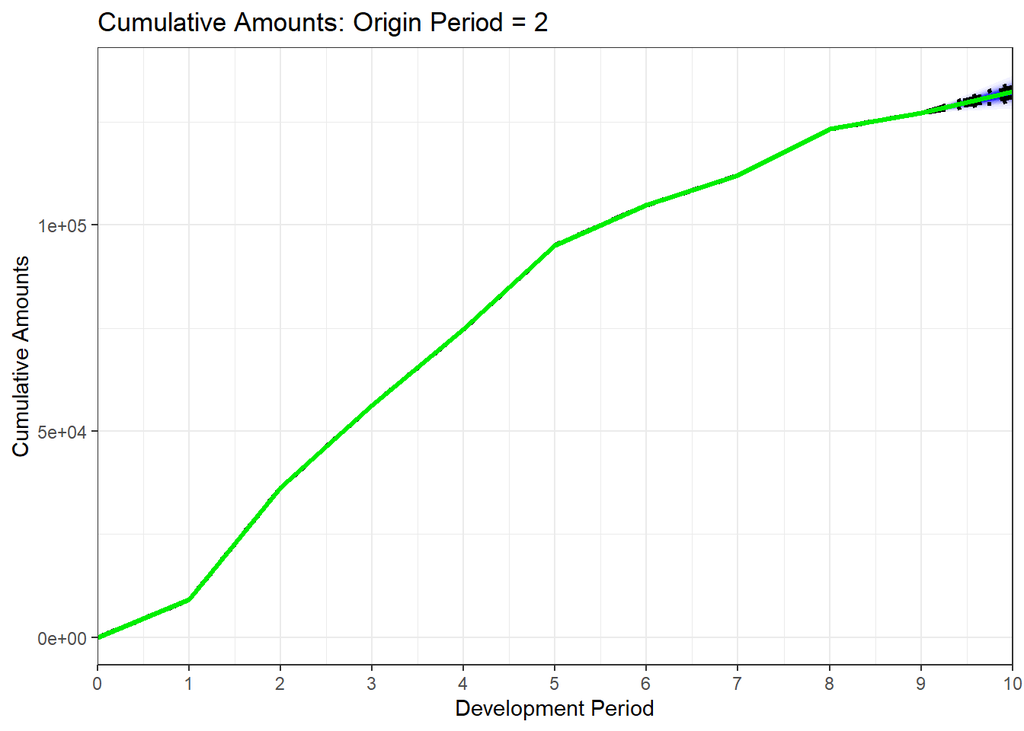

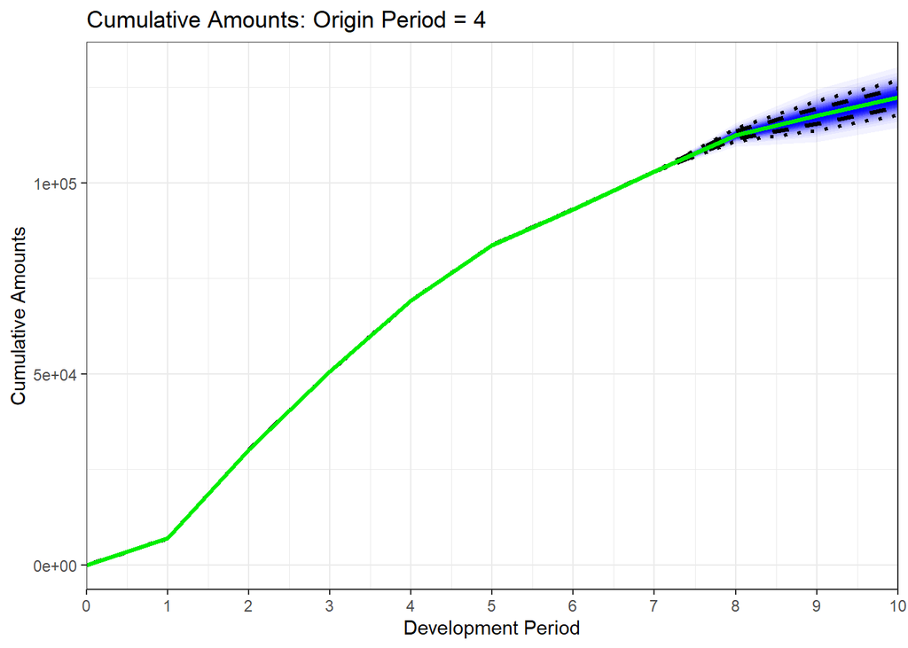

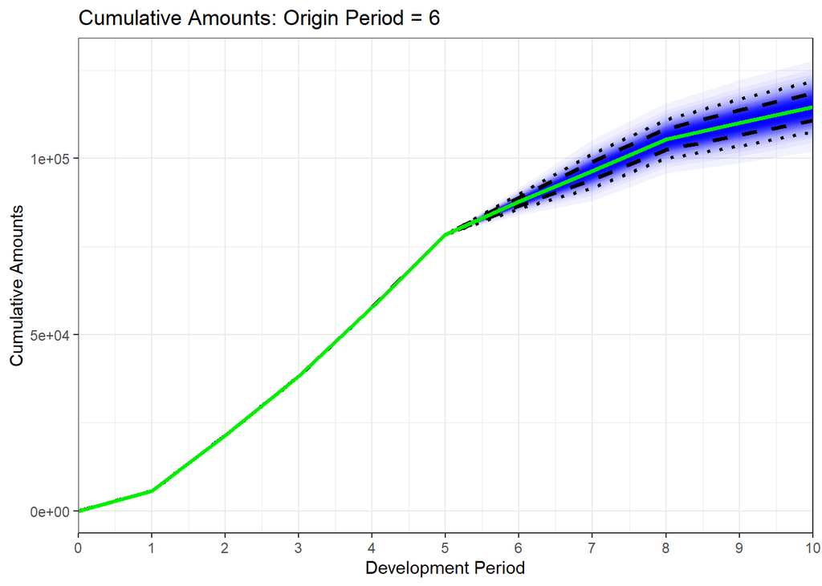

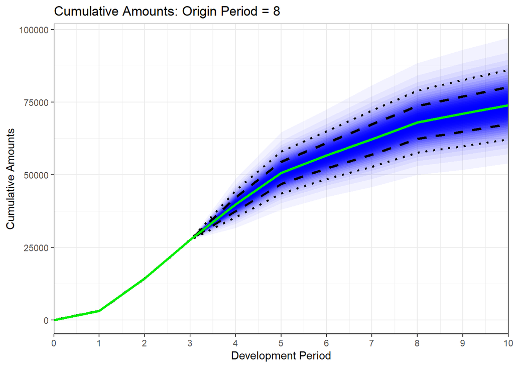

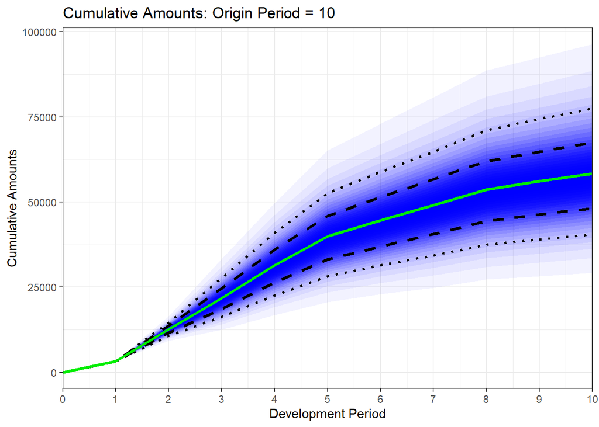

```r
BStrap_Cumulatives <- Mack_Bstrap_Result$Cumulatives

for (yr in seq(2, ncol(BStrap_Cumulatives), by = 2)) {
  print(plotDevelopmentGraph(BStrap_Cumulatives,yr))
}
```

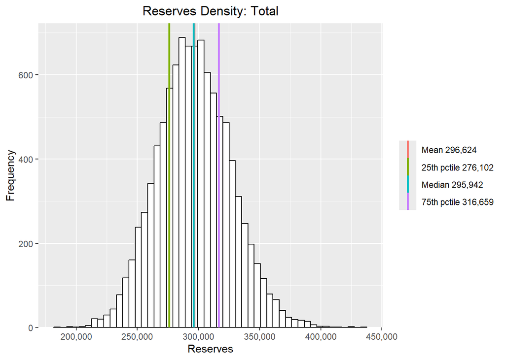

```r
# Histograms - Bootstrap undiscounted reserves
plotHistogram_Total(Mack_Bstrap_Result$TotalReserve)
```

```r
#plotHistogram_by_yr(Mack_Bstrap_Result$Reserves)
```

*Commentary:*

### Step 10: To further understand the impact of the variance parameters, manually adjust the variance parameters (Mack’s sigma) where appropriate:

```r
# Excluding link ratios obviously impacts the mean as well as the variance. The level of volatility can also be controlled by
# manually adjusting the parameters in the variance (ie Mack's sigma or sqrtScale of the ODP model).

# Initially set the user-defined variance parameters to the original values with all link ratios included,
# then reduce the sixth value that is causing the development graph to fan out significantly.

UserSqrtScale <- sigma_original
print("Original Mack's sigma parameters")
```

```
## [1] "Original Mack's sigma parameters"
```

```r
UserSqrtScale
```

```
## [1] 26.80080 31.10031 20.78941 15.94998 14.52081 54.58740 12.28647  6.43151  6.43151
```

```r
# Mack:
UserSqrtScale[6] <- 13
print("User-defined Mack's sigma parameters")
```

```
## [1] "User-defined Mack's sigma parameters"
```

```r
UserSqrtScale
```

```
## [1] 26.80080 31.10031 20.78941 15.94998 14.52081 13.00000 12.28647  6.43151  6.43151
```

```r
# Repeat bootstrapping with user-defined scale parameters

Indicators <- matrix(1,nrow(Triangle)-1, ncol(Triangle)-1) # include all data

Mack_Bstrap_Result <- Run_Bootstrap(Triangle, Mask=Indicators, method=method,
                               replications=replications, seed=seed, BootstrapDist=BootstrapDist,
                               ForecastDist=ForecastDist, UserSqrtScale=UserSqrtScale)

#Table of results
Table_2 <- cbind(round(Mack_Bstrap_Result$Latest,0), round(Mack_Bstrap_Result$Avg_Reserve,0),
                 round(Mack_Bstrap_Result$Latest+Mack_Bstrap_Result$Avg_Reserve,0),
                 round(Mack_Bstrap_Result$SD_Reserve,0), round(100*Mack_Bstrap_Result$CoV_Reserve,1))
Table_2_Totals <- cbind(round(sum(Mack_Bstrap_Result$Latest),0), round(Mack_Bstrap_Result$Avg_TotalReserve,0),
                        round(sum(Mack_Bstrap_Result$Latest)+Mack_Bstrap_Result$Avg_TotalReserve,0),
                        round(Mack_Bstrap_Result$SD_TotalReserve,0), round(100*Mack_Bstrap_Result$CoV_TotalReserve,1))
Table_2 <- rbind(Table_2, Table_2_Totals)
dimnames(Table_2) <- list(c(1:length(Triangle), "Total"), c("Latest", "Avg Reserves",
                                                            "Avg Ultimates", "Bstrap SD", "Reserves CoV %"))
names(dimnames(Table_2)) <- c("Year","Simulated (Undiscounted)")
Table_2
```

```
##        Simulated (Undiscounted)
## Year    Latest Avg Reserves Avg Ultimates Bstrap SD Reserves CoV %
##   1     131590            0        131590         0            0.0
##   2     127208         5150        132358      3270           63.5
##   3     155978        13456        169434      5188           38.6
##   4     102958        16867        119825      6254           37.1
##   5      90853        34638        125491     12094           34.9
##   6      78429        45001        123430     13469           29.9
##   7      43554        43494         87048     11481           26.4
##   8      27644        52094         79738     13060           25.1
##   9      15327        60895         76222     17078           28.0
##   10      3157        59606         62763     17350           29.1
##   Total 776698       331201       1107899     56370           17.0
```

```r
# Show set of summary statistics
ShowStats <- ShowSummaryStats(Mack_Bstrap_Result, Output="Reserves")
```

```
## [1] "Simulation Summary Statistics - Reserves"
##                              OP.1  OP.2  OP.3  OP.4  OP.5   OP.6   OP.7   OP.8   OP.9  OP.10  Total
## Mean                            0  5150 13456 16867 34638  45001  43494  52094  60895  59606 331201
## Standard Deviation              0  3270  5188  6254 12094  13469  11481  13060  17078  17350  56370
## Coefficient of Variation (%)  0.0  63.5  38.6  37.1  34.9   29.9   26.4   25.1   28.0   29.1   17.0
## Minimum                         0 -6516 -5946 -5953 -3856   2824   7952   9571   7240   7230 153951
## 0.5th Percentile                0 -3227   351  1222  5373  12864  16576  22452  23091  23234 197948
## 1st Percentile                  0 -2437  1491  2513  7931  15060  18710  24884  25732  26091 208435
## 5th Percentile                  0  -221  4992  6644 15128  23503  25794  31705  34728  33901 242023
## 10th Percentile                 0   982  6874  8903 19185  27968  29361  35843  39852  38549 261114
## 25th Percentile                 0  2938  9924 12621 26421  35648  35535  42948  48958  47286 292867
## 50th Percentile (Median)        0  5135 13387 16782 34503  44560  42890  51502  59743  58037 329008
## 75th Percentile                 0  7338 16977 21056 42552  53862  50933  60439  71614  70391 367484
## 90th Percentile                 0  9430 20160 24855 50058  62599  58385  69193  83021  82552 404128
## 95th Percentile                 0 10585 22096 27361 55303  67705  63310  74758  90594  90218 426976
## 99th Percentile                 0 12671 25486 31756 63785  77948  72516  85287 107152 106929 473226
## 99.5th Percentile               0 13541 26751 33280 67119  81707  75590  89584 112339 112369 488801
## Maximum                         0 17524 31990 41082 87128 109180 104048 103253 145694 143215 582477
```

```r
ShowStats <- ShowSummaryStats(Mack_Bstrap_Result, Output="Ultimates")
```

```
## [1] "Simulation Summary Statistics - Ultimates"
##                                OP.1   OP.2   OP.3   OP.4   OP.5   OP.6   OP.7   OP.8   OP.9  OP.10   Total
## Mean                         131590 132358 169434 119825 125491 123430  87048  79738  76222  62763 1107899
## Standard Deviation                0   3270   5188   6254  12094  13469  11481  13060  17078  17350   56370
## Coefficient of Variation (%)    0.0    2.5    3.1    5.2    9.6   10.9   13.2   16.4   22.4   27.6     5.1
## Minimum                      131590 120692 150032  97005  86997  81253  51506  37215  22567  10387  930649
## 0.5th Percentile             131590 123981 156329 104180  96226  91293  60130  50096  38418  26391  974646
## 1st Percentile               131590 124771 157469 105471  98784  93489  62264  52528  41059  29248  985133
## 5th Percentile               131590 126987 160970 109602 105981 101932  69348  59349  50055  37058 1018721
## 10th Percentile              131590 128190 162852 111861 110038 106397  72915  63487  55179  41706 1037812
## 25th Percentile              131590 130146 165902 115579 117274 114077  79089  70592  64285  50443 1069565
## 50th Percentile (Median)     131590 132343 169365 119740 125356 122989  86444  79146  75070  61194 1105706
## 75th Percentile              131590 134546 172955 124014 133405 132291  94487  88083  86941  73548 1144182
## 90th Percentile              131590 136638 176138 127813 140911 141028 101939  96837  98348  85709 1180826
## 95th Percentile              131590 137793 178074 130319 146156 146134 106864 102402 105921  93375 1203674
## 99th Percentile              131590 139879 181464 134714 154638 156377 116070 112931 122479 110086 1249924
## 99.5th Percentile            131590 140749 182729 136238 157972 160136 119144 117228 127666 115526 1265499
## Maximum                      131590 144732 187968 144040 177981 187609 147602 130897 161021 146372 1359175
```

*Commentary:*

If all link ratios are included again, but the value of Mack’s sigma is reduced manually from the original value of 55 to 13, the mean is unchanged from its original value (subject to simulation error), but the standard deviation and coefficient of variation are reduced.

Note also that there is less of an issue with negative reserves.

User-defined variance parameters are an alternative to excluding link ratios for controlling the level of volatility, and can be used carefully and knowledgeably once the drivers of volatility have been identified.